# Classification and regression trees for linguistic analysis

## Graphical parameters

Large trees can be unwieldy to plot, and the `partykit` package offers ways to adjust the graphical settings of your trees to help with presentation.

```r
help("party-plot")
```

Basic global parameters are specified with a gpar() object.

```r
`?`(gpar)
```

You can see the current settings like so.

```r
str(get.gpar())
```

```
List of 14
 $ fill      : chr "white"
 $ col       : chr "black"
 $ lty       : chr "solid"
 $ lwd       : num 1
 $ cex       : num 1
 $ fontsize  : num 12
 $ lineheight: num 1.2
 $ font      : int 1
 $ fontfamily: chr ""
 $ alpha     : num 1
 $ lineend   : chr "round"
 $ linejoin  : chr "round"
 $ linemitre : num 10
 $ lex       : num 1
 - attr(*, "class")= chr "gpar"
```

### Fonts

Font **size**, **face** (bold, italic), and family (serif, Times, etc.) can be changed with the following parameters.

- `cex`: Multiplier applied to fontsize
- `fontsize`: The size of text (in points)
- `fontface`: The specification of fontface can be an integer or a string. If an integer, then it follows the R base graphics standard: 1 = plain, 2 = **bold**, 3 = *italic*, 4 = *bold italic*. If a string, then valid values are: “plain”, “bold”, “italic”, “oblique”, and “bold.italic”.
- `fontfamily`: Changes to the fontfamily may be ignored by some devices. The fontfamily may be used to specify one of the Hershey Font families (e.g., HersheySerif) and this specification will be honoured on all devices.

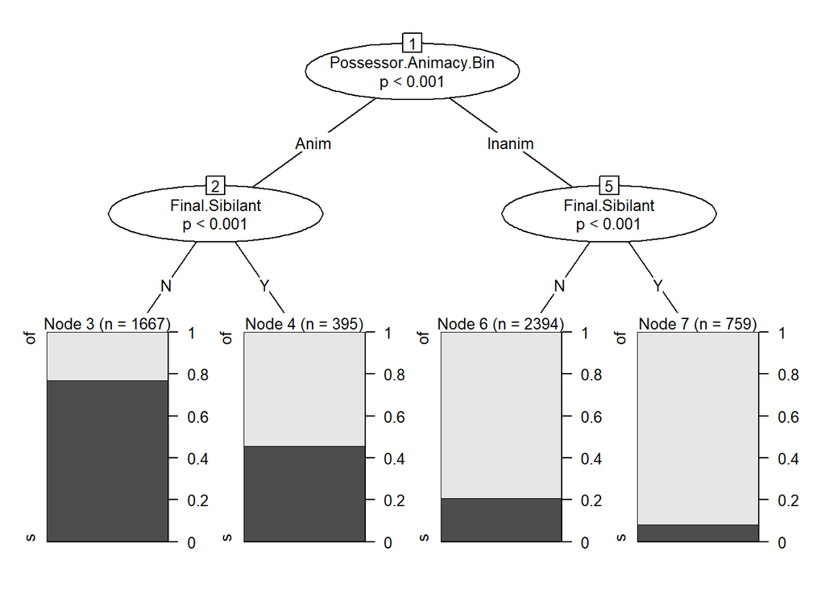

```r
# (cex is a multiplier)
plot(gen_ctree1, gp = gpar(cex = 0.8, fontfamily = "Times New Roman"))
```

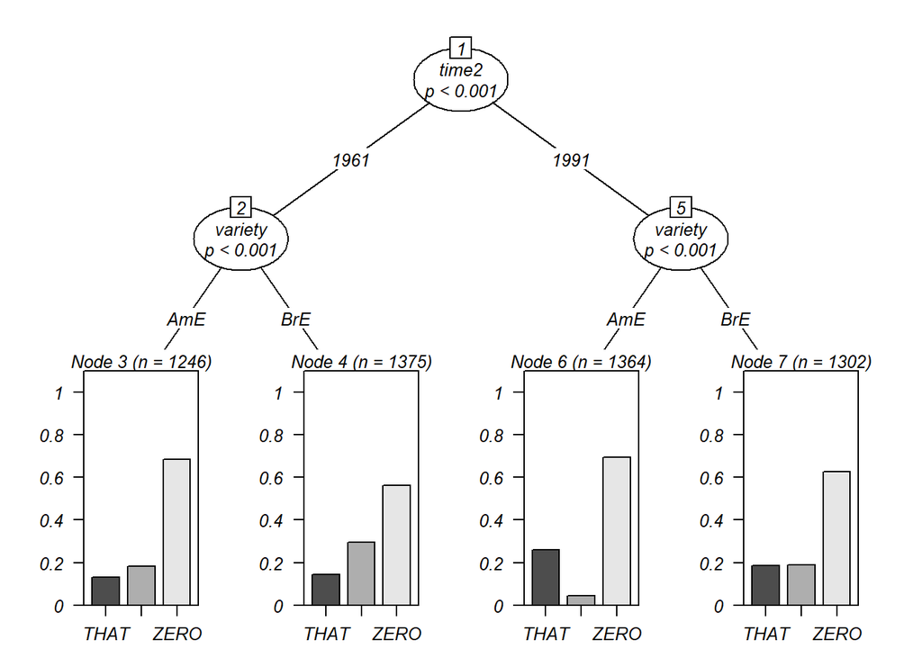

```r
plot(rel_ctree1, gp = gpar(cex = 0.8, fontface = "italic"))
```

### Line type & width (lex is a similar multiplier)

Line type (solid, dashed, etc.) and width can be adjusted with the `lty` and `lwd` or `lex` arguments respectively (`lex` is a multiplier similar to `cex`).

Line type can be specified using either text (“blank”, “solid”, “dashed”, “dotted”, “dotdash”, “longdash”, “twodash”) or number (0, 1, 2, 3, 4, 5, 6). Note that lty = “solid” is identical to `lty` = 1.

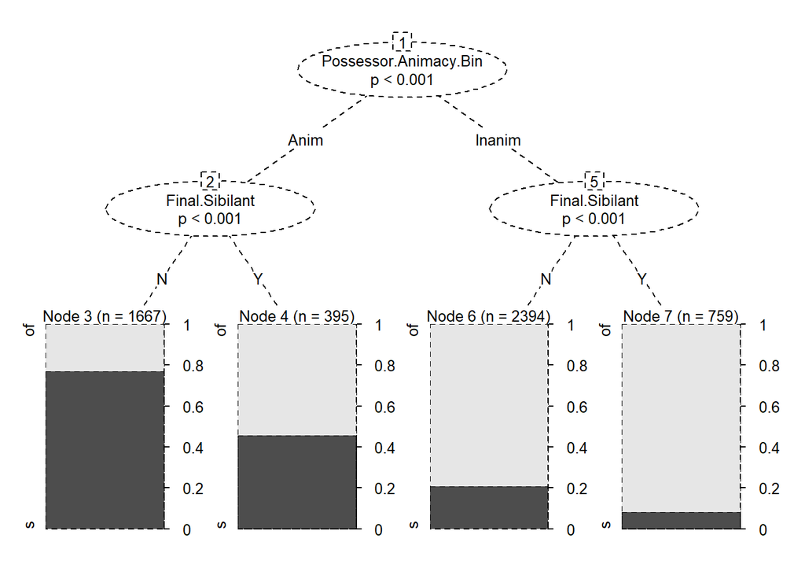

```r
plot(gen_ctree1, gp = gpar(cex = 0.8, lty = 2))  # dashed lines
```

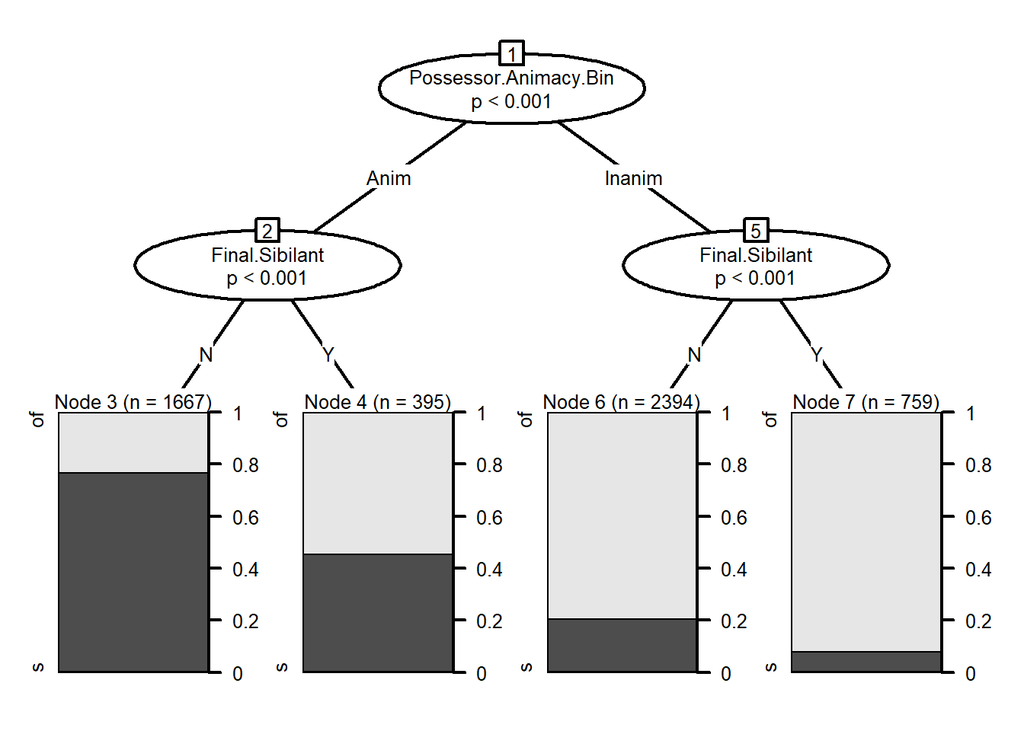

```r
plot(gen_ctree1, gp = gpar(cex = 0.8, lwd = 2))
```

### Colors

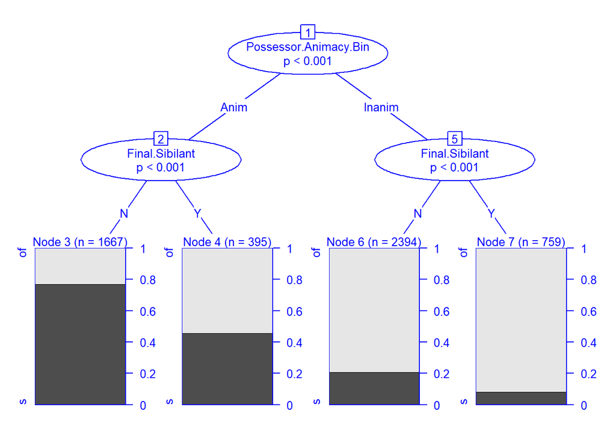

```r
plot(gen_ctree1, gp = gpar(cex = 0.8, col = "blue"))
```